# Environmental distances

# Introduction

Here we will use bioclimatic variables from worldclim to obtain a measure of climatic distance between localities where weevils were collected.

Let’s start by reading packages:

`r`r library(tidyverse) library(raster) library(sf) library(sp) library(rgbif) library(CoordinateCleaner) library(ggbiplot)

`r`r rm(list = ls())

# Downloading data from WorldClim

To start, we will download worldclim bioclimatic layers at 2.5 minute resolution from http://worldclim.org/version2.

Then, we will crop layers to our region of interest to reduce file size. The code to do so is commented out below, in this notebook we will simply read the smaller file to save time.

`r`r #bioclim = raster::stack(list.files(‘worldclim/wc2.0_2.5m_bio/’,full.names = T)) #bbox = raster::extent(c(xmin=-48,xmax=-32,ymin=-25,ymax=-4)) #cropped = raster::crop(bioclim,bbox) #writeRaster(cropped,‘./worldclim/wc2.0_2.5m_bio_cropped’,‘GTiff’) bioclim = raster::stack(‘worldclim/wc2.0_2.5m_bio_cropped.tif’)

# Correlation between bioclimatic variables

We will now download data for both **Syagrus coronata** and **Syagrus botryophora** from GBIF to understand how bioclimatic variables are correlted across the range of these species. Let’s download records and clean with coordinate cleaner:

`r`r gbif_data <- occ_search(scientificName = botryophora, limit = 5000, return = , hasCoordinate = T, country = ‘BR’) %>% bind_rows(occ_search(scientificName = coronata, limit = 5000, return = , hasCoordinate = T, country = ‘BR’)) %>% dplyr::select(species, decimalLongitude, decimalLatitude, countryCode) %>% filter(!is.na(decimalLongitude)) %>% filter(!is.na(decimalLatitude)) %>% mutate(countryCode = countrycode::countrycode(countryCode, origin = ‘iso2c’, destination = ‘iso3c’)) %>% clean_coordinates(lon = , lat = , countries = , species = , #outliers_method = ‘distance’, outliers_mtp = 1, value = ‘clean’) %>% filter(decimalLongitude>-50, decimalLatitude>-20) #for some reason, this is still not cleaned

```
Testing coordinate validity
Flagged 0 records.
Testing equal lat/lon
Flagged 0 records.
Testing zero coordinates
Flagged 0 records.
Testing country capitals
Flagged 0 records.
Testing country centroids
Flagged 6 records.
Testing sea coordinates
==================================================
Source: \/tmp/RtmpI8SbqP\, layer: \ne_50m_land\
Flagged 15 records.
Testing geographic outliers
Flagged 19 records.
Testing GBIF headquarters, flagging records around Copenhagen
Flagged 0 records.
Testing biodiversity institutions
Flagged 0 records.
Flagged 38 of 243 records, EQ = 0.16.
```

`r`r wm <- borders(, colour=50, fill=50) p = ggplot(gbif_data)+ coord_fixed(xlim = range(gbif_data$decimalLongitude), ylim = range(gbif_data$decimalLatitude))+ wm + geom_point(aes(x = decimalLongitude, y = decimalLatitude, color=species), size = 0.5) + scale_color_discrete(labels = c(`Syagrus botryophora` = . botryophora, `Syagrus coronata` = . coronata)) + xlab(‘Latitude’) + ylab(‘Longitude’) + theme_bw() + theme(legend.position = ‘bottom’, text=element_text(size=10), legend.text = element_text(face=‘italic’)) print(p) ggsave(filename = ‘./figures/bioclim_map.pdf’, plot = p, width = 17.8/2, height = 17.8*3/4, units=‘cm’, useDingbats=F)

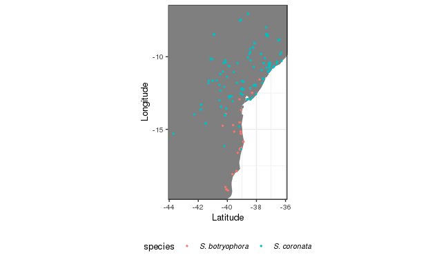

Now, let’s extract bioclimatic variables for these points:

`r`r bioclim_vars = gbif_data %>% st_as_sf(coords = c(‘decimalLongitude’, ‘decimalLatitude’), crs = 4326) %>% as(‘Spatial’) %>% raster::extract(x=bioclim) %>% as_tibble %>% rename_all(funs(str_extract(.,‘[0-9]+$’) %>% str_c(‘bio’,.)))

[output not shown]

`r`r bioclim_vars

| bio1 | bio2 | bio3 | bio4 | bio5 | bio6 | bio7 | bio8 | bio9 | bio10 | bio11 | bio12 | bio13 | bio14 | bio15 | bio16 | bio17 | bio18 | bio19 |
| --- | --- | --- | --- | --- | --- | --- | --- | --- | --- | --- | --- | --- | --- | --- | --- | --- | --- | --- |
| 24.30667 | 6.025333 | 64.15390 | 126.1321 | 28.82800 | 19.43600 | 9.391998 | 24.13267 | 23.23533 | 25.74733 | 22.69533 | 2203 | 231 | 135 | 19.06681 | 669 | 438 | 543 | 588 |
| 19.42600 | 9.130667 | 66.62775 | 165.4206 | 26.18000 | 12.47600 | 13.704000 | 20.72267 | 17.49333 | 21.19400 | 17.13067 | 763 | 114 | 34 | 41.77494 | 305 | 113 | 226 | 134 |
| 23.68733 | 8.724000 | 60.56651 | 193.3752 | 31.10400 | 16.70000 | 14.403999 | 25.13733 | 21.81667 | 25.98667 | 21.24267 | 1227 | 182 | 43 | 47.63988 | 515 | 160 | 356 | 161 |
| 23.46083 | 8.975667 | 61.83292 | 188.1327 | 30.89200 | 16.37600 | 14.516001 | 24.84133 | 21.60067 | 25.69800 | 21.05333 | 1174 | 177 | 36 | 51.47803 | 508 | 139 | 354 | 140 |
| 21.75767 | 7.442000 | 64.87099 | 146.9975 | 27.26800 | 15.79600 | 11.472000 | 22.83133 | 20.72533 | 23.40267 | 19.78533 | 1297 | 137 | 76 | 18.84608 | 388 | 258 | 366 | 296 |
| 21.06250 | 7.149000 | 63.71658 | 149.1848 | 26.14000 | 14.92000 | 11.219999 | 22.21333 | 19.20267 | 22.67133 | 19.05200 | 821 | 120 | 37 | 36.91954 | 304 | 131 | 253 | 142 |
| 23.08983 | 7.788999 | 65.58605 | 149.2900 | 28.84800 | 16.97200 | 11.875999 | 24.23200 | 21.37067 | 24.74067 | 21.06933 | 1286 | 140 | 69 | 20.31159 | 395 | 252 | 354 | 264 |
| 23.62617 | 8.387000 | 62.05239 | 162.0182 | 29.77200 | 16.25600 | 13.515999 | 23.20667 | 22.49133 | 25.29133 | 21.43200 | 942 | 116 | 46 | 26.64281 | 311 | 152 | 226 | 239 |
| 24.24167 | 6.939744 | 61.91946 | 155.9843 | 29.94615 | 18.73846 | 11.207693 | 22.59359 | 25.90257 | 26.03974 | 22.28461 | 1627 | 207 | 68 | 32.21848 | 589 | 260 | 270 | 523 |
| 23.94183 | 8.427000 | 65.98028 | 153.8889 | 29.79200 | 17.02000 | 12.771999 | 23.67267 | 25.14267 | 25.55533 | 21.91933 | 1511 | 216 | 71 | 38.45855 | 587 | 255 | 284 | 471 |

[output cut: 191 more lines]

With this table, we can do a PCA to see which variables are correlated:

`r`r bc_mat = bioclim_vars %>% as.matrix PCA = prcomp(bc_mat) biplot(PCA,xlabs=rep(‘.’,nrow(bc_mat)))

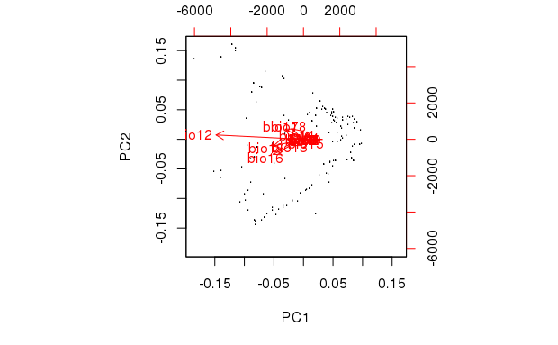

`r`r PCA$sdev^2/sum(PCA$sdev^2)

```
 [1] 9.106931e-01 5.112507e-02 3.175865e-02 4.711242e-03 6.906936e-04 5.922668e-04
 [7] 1.948220e-04 1.488012e-04 3.247693e-05 2.661601e-05 1.844426e-05 5.410419e-06
[13] 1.800509e-06 5.424930e-07 4.878069e-08 1.036396e-08 5.612796e-09 1.825925e-09
[19] 7.957725e-20
```

`r`r PCA$rotation[,1:2]

```
                PC1           PC2
bio1  -0.0017013153 -0.0035959654
bio2   0.0023526867 -0.0013236548
bio3   0.0006584886 -0.0043784192
bio4   0.0166545710  0.0534186684
bio5  -0.0002218087 -0.0035820286
bio6  -0.0037161785 -0.0023382247
bio7   0.0034943698 -0.0012438039
bio8  -0.0007962878 -0.0004806212
bio9  -0.0029402231 -0.0084658276
bio10 -0.0016981310 -0.0028963955
bio11 -0.0020515078 -0.0042713458
bio12 -0.8710631554  0.1853706039
bio13 -0.1080982620 -0.2624894332
bio14 -0.0545837955  0.1303774188
bio15  0.0167913412 -0.1366156231
bio16 -0.3014639975 -0.6292650665
bio17 -0.1801009986  0.4322325596
bio18 -0.1180548495  0.4458933948
bio19 -0.2978588042 -0.2764936166
```

`r`r p = ggbiplot(PCA, groups = gbif_data$species, scale = 1) + scale_color_discrete(guide=‘none’) + theme(text = element_text(size=10)) print(p) ggsave(filename = ‘./figures/biplot.pdf’, plot = p, width = 17.8/2, height = 17.8*3/4, units=‘cm’, useDingbats=F)

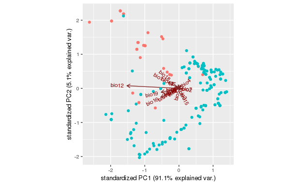

Almost all of the variation in climate can be explained simply by BIO12: Annual Precipitation. Therefore, we will use only BIO12 to calculate environmental distances.

# Calculation of climatic distances

To extract bioclimatic variables, we will first load plant data to extract localities of collection:

`r`r collection_points = readr::read_csv(‘angsd_plants/plant_data.csv’) %>% dplyr::select(population = pop_id_thesis, lat, lon) %>% distinct collection_points

| population | lat | lon |
| --- | --- | --- |
| P9 | -15.389457 | -42.80203 |
| P5 | -12.454400 | -40.54800 |
| P20 | -10.536483 | -39.37708 |
| P15 | -9.760979 | -36.50717 |
| P10 | -17.121331 | -39.38056 |
| P6 | -11.628016 | -41.15346 |
| P19 | -9.740904 | -38.23869 |
| P17_hyb | -8.976726 | -36.51673 |
| P3 | -15.304636 | -39.13031 |
| P3 | -15.304414 | -39.13019 |

[output cut: 32 more lines]

Now let’s use these localities to extract bioclimatic variables from the raster:

`r`r bioclim_vars = collection_points %>% st_as_sf(coords = c(‘lon’, ‘lat’), crs = 4326) %>% as(‘Spatial’) %>% raster::extract(x=bioclim) %>% as_tibble %>% rename_all(funs(str_extract(.,‘[0-9]+$’) %>% str_c(‘bio’,.))) %>% bind_cols(collection_points) %>% group_by(population) %>% summarise_all(mean) bioclim_vars

| population | bio1 | bio2 | bio3 | bio4 | bio5 | bio6 | bio7 | bio8 | bio9 | bio10 | bio11 | bio12 | bio13 | bio14 | bio15 | bio16 | bio17 | bio18 | bio19 | lat | lon |
| --- | --- | --- | --- | --- | --- | --- | --- | --- | --- | --- | --- | --- | --- | --- | --- | --- | --- | --- | --- | --- | --- |
| P1 | 23.95283 | 9.519166 | 63.83121 | 181.5641 | 31.533 | 16.6200 | 14.913000 | 25.27617 | 21.58383 | 26.11800 | 21.58383 | 1211.75 | 168.25 | 43.25 | 44.81322 | 488.25 | 159.25 | 362.25 | 159.25 | -18.350829 | -40.14971 |
| P10 | 24.22517 | 7.801667 | 64.84099 | 157.3894 | 30.300 | 18.2680 | 12.032000 | 24.73800 | 22.15667 | 26.06400 | 22.15667 | 1276.00 | 150.00 | 71.00 | 20.26588 | 396.00 | 257.00 | 307.00 | 257.00 | -17.121638 | -39.38125 |
| P11 | 22.20117 | 7.131000 | 63.87495 | 148.8808 | 27.448 | 16.2840 | 11.164000 | 23.31933 | 20.33133 | 23.82267 | 20.22200 | 937.00 | 122.00 | 45.00 | 29.46537 | 318.00 | 165.00 | 270.00 | 186.00 | -13.926809 | -40.01808 |
| P12 | 23.47350 | 6.097667 | 63.54383 | 132.2177 | 27.920 | 18.3240 | 9.596001 | 22.32000 | 23.15133 | 24.95467 | 21.77133 | 1933.00 | 214.00 | 114.00 | 21.88348 | 624.00 | 376.00 | 460.00 | 574.00 | -13.341591 | -39.19553 |
| P13 | 23.53000 | 8.534000 | 64.14612 | 154.6913 | 29.548 | 16.2440 | 13.304001 | 23.26667 | 23.39733 | 25.08267 | 21.46133 | 1226.00 | 175.00 | 59.00 | 36.26298 | 464.00 | 204.00 | 259.00 | 356.00 | -12.132031 | -38.48515 |
| P15 | 23.90142 | 8.684834 | 61.44722 | 160.2938 | 30.506 | 16.3720 | 14.134001 | 22.42967 | 25.31633 | 25.53667 | 21.75267 | 918.00 | 160.00 | 19.00 | 69.20620 | 459.00 | 68.00 | 137.50 | 384.50 | -9.729299 | -36.51267 |
| P17_cor | 20.88083 | 7.945667 | 56.62534 | 148.4247 | 27.592 | 13.5600 | 14.031999 | 19.49600 | 21.91200 | 22.35667 | 18.96333 | 946.00 | 152.00 | 18.00 | 58.55034 | 415.00 | 75.00 | 131.00 | 291.00 | -8.931129 | -36.49731 |
| P17_hyb | 20.79583 | 7.937000 | 55.72171 | 149.6894 | 27.620 | 13.3760 | 14.244000 | 19.41600 | 21.82333 | 22.28867 | 18.85467 | 978.00 | 156.00 | 19.00 | 58.99908 | 435.00 | 79.00 | 134.00 | 300.00 | -8.976614 | -36.51686 |
| P19 | 24.13267 | 10.362000 | 61.91443 | 183.9117 | 31.860 | 15.1240 | 16.736000 | 24.58600 | 24.48467 | 25.88400 | 21.57600 | 611.00 | 85.00 | 12.00 | 44.88385 | 235.00 | 60.00 | 158.00 | 158.00 | -9.740904 | -38.23869 |
| P2 | 24.57233 | 10.448667 | 66.28182 | 175.0614 | 32.236 | 16.4720 | 15.764000 | 25.86467 | 22.07733 | 26.37467 | 22.07733 | 802.00 | 138.00 | 19.00 | 61.84888 | 368.00 | 71.00 | 261.00 | 71.00 | -16.150136 | -40.21495 |

[output cut: 8 more lines]

Now let’s pull BIO12 and calculate pairwise distances.

`r`r clim_dist = dist(bioclim_vars$bio12) %>% as.matrix() rownames(clim_dist) = colnames(clim_dist) = bioclim_vars$population clim_dist

```
            P1    P10    P11     P12    P13     P15 P17_cor P17_hyb     P19
P1        0.00  64.25 274.75  721.25  14.25  293.75  265.75  233.75  600.75
P10      64.25   0.00 339.00  657.00  50.00  358.00  330.00  298.00  665.00
P11     274.75 339.00   0.00  996.00 289.00   19.00    9.00   41.00  326.00
P12     721.25 657.00 996.00    0.00 707.00 1015.00  987.00  955.00 1322.00
P13      14.25  50.00 289.00  707.00   0.00  308.00  280.00  248.00  615.00
P15     293.75 358.00  19.00 1015.00 308.00    0.00   28.00   60.00  307.00
P17_cor 265.75 330.00   9.00  987.00 280.00   28.00    0.00   32.00  335.00
P17_hyb 233.75 298.00  41.00  955.00 248.00   60.00   32.00    0.00  367.00
P19     600.75 665.00 326.00 1322.00 615.00  307.00  335.00  367.00    0.00
P2      409.75 474.00 135.00 1131.00 424.00  116.00  144.00  176.00  191.00
P20     644.75 709.00 370.00 1366.00 659.00  351.00  379.00  411.00   44.00
P3      489.25 425.00 764.00  232.00 475.00  783.00  755.00  723.00 1090.00
P4      659.75 724.00 385.00 1381.00 674.00  366.00  394.00  426.00   59.00
P5      540.75 605.00 266.00 1262.00 555.00  247.00  275.00  307.00   60.00
P6      377.75 442.00 103.00 1099.00 392.00   84.00  112.00  144.00  223.00
P7      463.25 527.50 188.50 1184.50 477.50  169.50  197.50  229.50  137.50
P8        2.95  67.20 271.80  724.20  17.20  290.80  262.80  230.80  597.80
P9      362.75 427.00  88.00 1084.00 377.00   69.00   97.00  129.00  238.00
             P2     P20      P3      P4      P5      P6      P7     P8      P9
P1       409.75  644.75  489.25  659.75  540.75  377.75  463.25   2.95  362.75
P10      474.00  709.00  425.00  724.00  605.00  442.00  527.50  67.20  427.00
P11      135.00  370.00  764.00  385.00  266.00  103.00  188.50 271.80   88.00
P12     1131.00 1366.00  232.00 1381.00 1262.00 1099.00 1184.50 724.20 1084.00
P13      424.00  659.00  475.00  674.00  555.00  392.00  477.50  17.20  377.00
P15      116.00  351.00  783.00  366.00  247.00   84.00  169.50 290.80   69.00
P17_cor  144.00  379.00  755.00  394.00  275.00  112.00  197.50 262.80   97.00
P17_hyb  176.00  411.00  723.00  426.00  307.00  144.00  229.50 230.80  129.00
P19      191.00   44.00 1090.00   59.00   60.00  223.00  137.50 597.80  238.00
P2         0.00  235.00  899.00  250.00  131.00   32.00   53.50 406.80   47.00
P20      235.00    0.00 1134.00   15.00  104.00  267.00  181.50 641.80  282.00
P3       899.00 1134.00    0.00 1149.00 1030.00  867.00  952.50 492.20  852.00
P4       250.00   15.00 1149.00    0.00  119.00  282.00  196.50 656.80  297.00
P5       131.00  104.00 1030.00  119.00    0.00  163.00   77.50 537.80  178.00
P6        32.00  267.00  867.00  282.00  163.00    0.00   85.50 374.80   15.00
P7        53.50  181.50  952.50  196.50   77.50   85.50    0.00 460.30  100.50
P8       406.80  641.80  492.20  656.80  537.80  374.80  460.30   0.00  359.80
P9        47.00  282.00  852.00  297.00  178.00   15.00  100.50 359.80    0.00
```

Finally, let’s calculate pairwise geographical distances from geographical coordinates. We will project them to UTM first to obtain Euclidean distances.

`r`r mean_locs = collection_points %>% group_by(population) %>% summarise_all(mean) geo_dist = mean_locs %>% st_as_sf(coords = c(‘lon’, ‘lat’), crs = 4326) %>% st_transform(st_crs(32724)) %>% st_distance() %>% units::set_units(‘km’) colnames(geo_dist) = rownames(geo_dist) = mean_locs$population geo_dist

```
Units: [km]
                P1      P10      P11       P12      P13        P15     P17_cor
P1         0.00000 158.5398 489.6523 563.46373 710.6992 1031.28721 1114.220698
P10      158.53978   0.0000 359.9433 418.58024 560.2314  874.66427  958.393435
P11      489.65230 359.9433   0.0000 110.02331 258.8873  601.10376  672.863694
P12      563.46373 418.5802 110.0233   0.00000 154.3957  495.20971  569.886467
P13      710.69917 560.2314 258.8873 154.39575   0.0000  342.22339  415.548638
P15     1031.28721 874.6643 601.1038 495.20971 342.2234    0.00000   88.343246
P17_cor 1114.22070 958.3934 672.8637 569.88647 415.5486   88.34325    0.000000
P17_hyb 1108.75315 952.9353 667.4990 564.46428 410.1334   83.29445    5.473509
P19      974.32998 825.5655 501.8090 411.59312 265.7712  189.40153  211.232774
P2       243.60431 139.4931 246.8636 329.46331 482.0179  815.81743  894.723615
P20      868.34389 728.2977 381.3570 310.81554 201.4898  326.32640  362.403500
P3       353.84452 202.6080 179.8152 217.33180 357.9243  679.37755  761.201548
P4       611.44660 477.6676 122.2697  92.98647 169.7364  502.39620  567.730249
P5       653.76809 531.3312 172.7001 176.52546 227.1487  533.94535  589.976017
P6       751.57321 636.9816 282.5201 284.89138 295.9086  549.36085  590.783405
P7       533.60243 465.2079 243.7591 340.53425 459.2438  784.63708  842.494693
P8        88.02409 232.0176 576.0400 646.44869 791.2744 1106.03112 1190.143928
P9       432.87781 412.9168 340.9408 450.30935 589.8511  926.85955  990.479794
            P17_hyb       P19       P2      P20       P3        P4        P5
P1      1108.753147  974.3300 243.6043 868.3439 353.8445 611.44660 653.76809
P10      952.935322  825.5655 139.4931 728.2977 202.6080 477.66761 531.33120
P11      667.499044  501.8090 246.8636 381.3570 179.8152 122.26971 172.70015
P12      564.464281  411.5931 329.4633 310.8155 217.3318  92.98647 176.52546
P13      410.133397  265.7712 482.0179 201.4898 357.9243 169.73636 227.14873
P15       83.294455  189.4015 815.8174 326.3264 679.3776 502.39620 533.94535
P17_cor    5.473509  211.2328 894.7236 362.4035 761.2015 567.73025 589.97602
P17_hyb    0.000000  207.1749 889.2598 358.0658 755.7292 562.50354 585.02853
P19      207.174863    0.0000 740.4831 152.6121 623.0175 385.51216 391.96463
P2       889.259795  740.4831   0.0000 627.4649 148.8154 369.06356 410.42959
P20      358.065801  152.6121 627.4649   0.0000 528.0766 259.40157 247.58474
P3       755.729177  623.0175 148.8154 528.0766   0.0000 285.30059 350.45016
P4       562.503544  385.5122 369.0636 259.4016 285.3006   0.00000  83.96369
P5       585.028532  391.9646 410.4296 247.5847 350.4502  83.96369   0.00000
P6       586.373060  381.0571 510.4158 228.5713 461.7496 192.25482 112.63603
P7       837.527150  643.3211 325.8982 495.0891 368.2241 289.50913 252.58203
P8      1184.690379 1056.0200 330.8859 953.2788 433.3673 697.45270 741.28314
P9       985.341666  797.7850 289.8135 653.1636 394.0724 424.47008 406.24890
              P6       P7         P8       P9
P1      751.5732 533.6024   88.02409 432.8778
P10     636.9816 465.2079  232.01764 412.9168
P11     282.5201 243.7591  576.04001 340.9408
P12     284.8914 340.5343  646.44869 450.3093
P13     295.9086 459.2438  791.27439 589.8511
P15     549.3608 784.6371 1106.03112 926.8596
P17_cor 590.7834 842.4947 1190.14393 990.4798
P17_hyb 586.3731 837.5272 1184.69038 985.3417
P19     381.0571 643.3211 1056.02003 797.7850
P2      510.4158 325.8982  330.88587 289.8135
P20     228.5713 495.0891  953.27882 653.1636
P3      461.7496 368.2241  433.36726 394.0724
P4      192.2548 289.5091  697.45270 424.4701
P5      112.6360 252.5820  741.28314 406.2489
P6        0.0000 288.1371  839.54937 453.1960
P7      288.1371   0.0000  619.00710 165.4702
P8      839.5494 619.0071    0.00000 510.4710
P9      453.1960 165.4702  510.47099   0.0000
```

Finally, let’s save the distance matrices to use later in BEDASSLE model

`r`r save(geo_dist,clim_dist,file = ‘worldclim/distances.Rdata’)